# How the top 25% students performance in China and New Zealand

## by (Ellen Zhang)

## Investigation Overview

> In this investigation, I wanted to look at how the top 25% students in China and New Zealand do would improve the math performance. The main focus was on the one academic performanc( Change and Relationships, Quantity, Space and Shape, Uncertainty and Data) and the two of categories of students: Average math performance, Math anxiety category(Worry That It Will Be Difficult, Get Very Tense, Get Very Nervous, Feel Helpless) and Math behaviours category (Talk about Maths with Friends, Help Friends with Maths, Extracurricular Activity, Participate in Competitions, Study More Than 2 Extra Hours a Day, Play Chess, Computer programming, Participate in Math Club ).

## Dataset Overview

> PISA is a survey of students' skills and knowledge as they approach the end of compulsory education. It is not a conventional school test. Rather than examining how well students have learned the school curriculum, it looks at how well prepared they are for life beyond school.

> Around 510,000 students in 65 economies took part in the PISA 2012 assessment of reading, mathematics and science representing about 28 million 15-year-olds globally. Of those economies, 44 took part in an assessment of creative problem solving and 18 in an assessment of financial literacy..

> In this investigate, i just focus on math-related data.

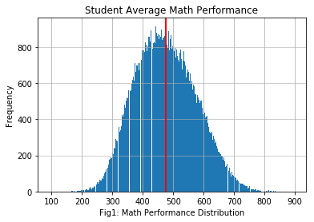

```python
df_iod['AMP'].plot.hist(grid=True, bins=500, rwidth=0.95)
plt.axvline(df_iod['AMP'].mean(), color='r',  linewidth=2)
plt.title('Student Average Math Performance')
plt.xlabel('Fig1: Math Performance Distribution')
plt.ylabel('Frequency')
plt.grid(axis='y', alpha=0.75)
plt.show()
```

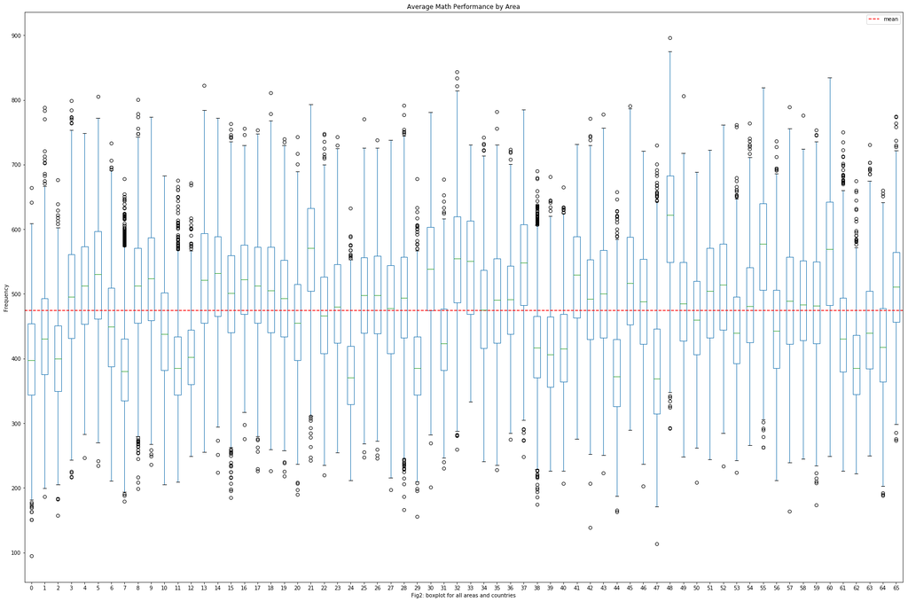

```python
# Boxplot for all the attendance

plt.rcParams["figure.figsize"] = [30, 20]
data = pd.concat(area_amp, axis=1, sort=False)
data.columns = range(0,len(area))
# plt.axhline(df_china['AMP'].mean(), color='y',  linewidth=2)
ax = data.plot.box()
ax.axhline(y= df_iod['AMP'].mean(),color='r', ls='--', label='mean')
ax.set_title('Average Math Performance by Area')
plt.xlabel('Fig2: boxplot for all areas and countries')
plt.ylabel('Frequency')

plt.legend()
plt.show()
```

[figure not shown]

```python
# China amp against New Zealand

plt.rcParams["figure.figsize"] = [8, 8]

area_sh_nz=[area_amp[49], area_amp[44]]
df_sh_nz = pd.concat(area_sh_nz, axis=1, sort=False)
df_sh_nz.columns = ['Shang Hai','New Zealand']
ax= df_sh_nz.plot.box()
ax.set_title('Boxplot for Average Math Performance by area or country')
ax.set_xlabel('Fig3: AMP: China against New Zealand')
ax.set_ylabel('Frequency')
plt.show()
```

## Very interesting founding 1

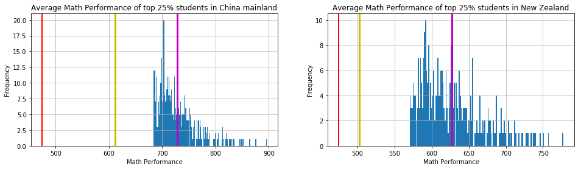

```python
plt.rcParams["figure.figsize"] = [16, 4]

# plt.figure(figsize=(7, 4))
ax = plt.subplot(121)

df_ch_top25['AMP'].plot.hist(grid=True, bins=150, rwidth=0.99)
plt.axvline(df_iod['AMP'].mean(), color='r',  linewidth=2)
plt.axvline(df_ch['AMP'].mean(), color='y',  linewidth=3)
plt.axvline(df_ch_top25['AMP'].mean(), color='m',  linewidth=3)

plt.title('Average Math Performance of top 25% students in China mainland')
plt.xlabel('Math Performance')
plt.ylabel('Frequency')

plt.grid(axis='y', alpha=0.75)

plt.subplot(122)
df_nz_top25['AMP'].plot.hist(grid=True, bins=150, rwidth=0.99)
plt.axvline(df_iod['AMP'].mean(), color='r',  linewidth=2)
plt.axvline(df_nz['AMP'].mean(), color='y',  linewidth=3)
plt.axvline(df_nz_top25['AMP'].mean(), color='m',  linewidth=3)

plt.title('Average Math Performance of top 25% students in New Zealand')
plt.xlabel('Math Performance')
plt.ylabel('Frequency')

plt.grid(axis='y', alpha=0.75)
plt.show()
```

## Very interesting founding 2

In New Zealand, Math behaviours has a stronger effect on math performance than in China. As I know, there is very common for students to do a lot extra activities related to math. Their math grade won't improve much more even if attending more activities. But in New Zealand, as long as the students would love to do more about math, it would be improve their math performance.

And we also see that math anxiety has a little negative relationship with math activity. That means the students work harder will decrease their anxiety. In China, this relationship(-0.379) is stronger than in New Zealand(-0.229). I guess that math studying in New Zealand is much happier than in China. The competition between Chinese students is too stressful.

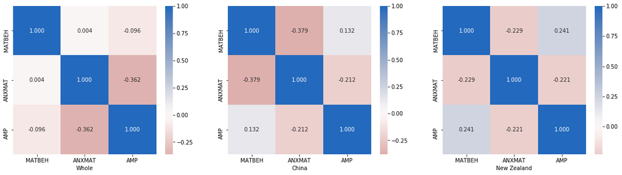

```python
plt.rcParams["figure.figsize"] = [20, 5]

ax = plt.subplot(131)

sns.heatmap(df_iod[numeric_vars].corr(), annot = True, fmt = '.3f',
           cmap = 'vlag_r', center = 0)

plt.xlabel('Whole')

ax = plt.subplot(132)

sns.heatmap(df_ch_top25[numeric_vars].corr(), annot = True, fmt = '.3f',
           cmap = 'vlag_r', center = 0)
plt.xlabel('China')

ax = plt.subplot(133)

sns.heatmap(df_nz_top25[numeric_vars].corr(), annot = True, fmt = '.3f',
           cmap = 'vlag_r', center = 0)

plt.xlabel('New Zealand')
plt.show()
```

## Average Math Performance against Math anxiety and Math activity

> Always to help friends study math and talk math with friends are two effective ways to improve their math performance. So the study buddy is a really good approach to help students with each other.

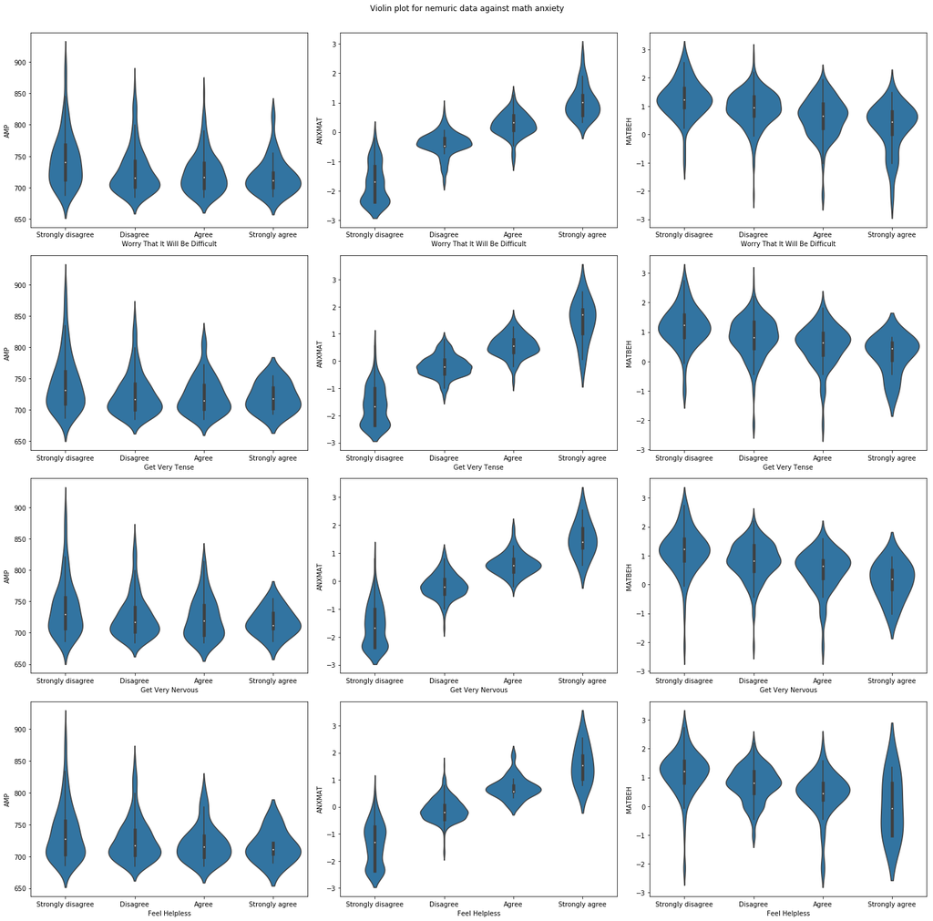

```python
fig, ax = plt.subplots(ncols = 3, nrows = len(categoric_vars_anxiety) , figsize = [20,20])

default_color = sns.color_palette()[0]

fig.suptitle('Violin plot for nemuric data against math anxiety')

for i in range(len(categoric_vars_anxiety)):
    var = categoric_vars_anxiety[i]
    sns.violinplot(data = df_ch_top25, x = var, y = 'AMP', ax = ax[i,0],
               color = default_color)

    sns.violinplot(data = df_ch_top25, x = var, y = 'ANXMAT', ax = ax[i,1],
               color = default_color)

    sns.violinplot(data = df_ch_top25, x = var, y = 'MATBEH', ax = ax[i,2],
               color = default_color)

fig.tight_layout()
fig.subplots_adjust(top=0.95)
plt.show()
```

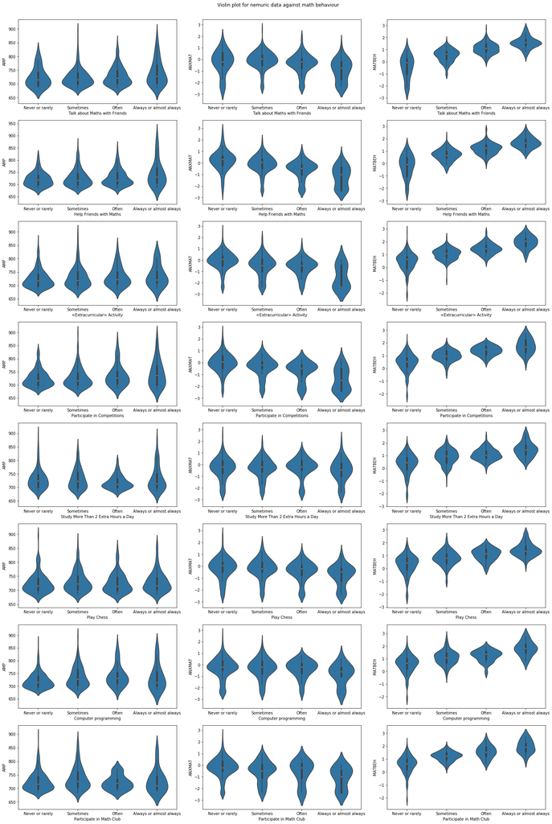

```python
fig, ax = plt.subplots(ncols = 3, nrows = len(categoric_vars_behaviour) , figsize = [20,30])

fig.suptitle('Violin plot for nemuric data against math behaviour')

for i in range(len(categoric_vars_behaviour)):
    var = categoric_vars_behaviour[i]
    sns.violinplot(data = df_ch_top25, x = var, y = 'AMP', ax = ax[i,0],
               color = default_color)


    sns.violinplot(data = df_ch_top25, x = var, y = 'ANXMAT', ax = ax[i,1],
               color = default_color)

    sns.violinplot(data = df_ch_top25, x = var, y = 'MATBEH', ax = ax[i,2],
               color = default_color)

fig.tight_layout()
fig.subplots_adjust(top=0.96)
plt.show()
```